# week_12_features_categorical

## CMPINF 2100 Week 12

### Working with CATEGORICAL or NON-NUMERIC Inputs

You will learn how FEATURES are generated to allow NON-NUMERIC values to be used in LINEAR MODELS!!!

We need these new types of features because ULTIMATELY linear models require MULTIPLYING SLOPES with NUMERIC INPUTS!!!

The models cannot handle non-numeric input values by themselves!!!

## Import Modules

```python
import numpy as np
import pandas as pd
import matplotlib.pyplot as plt

import seaborn as sns
```

```python
import statsmodels.formula.api as smf
import statsmodels.api as sm
```

## Read data

```python
df = pd.read_csv("week_11_categorical_input.csv")
```

```python
df.info()
```

```
<class 'pandas.core.frame.DataFrame'>
RangeIndex: 155 entries, 0 to 154
Data columns (total 2 columns):
 #   Column  Non-Null Count  Dtype
---  ------  --------------  -----
 0   x       155 non-null    object
 1   y       155 non-null    float64
dtypes: float64(1), object(1)
memory usage: 2.5+ KB
```

```python
df
```

|  | x | y |
| --- | --- | --- |
| 0 | A | 103.324129 |
| 1 | G | 96.530846 |
| 2 | D | 95.772873 |
| 3 | C | 100.190541 |
| 4 | J | 129.608242 |
| ... | ... | ... |
| 150 | B | 92.286905 |
| 151 | I | 74.533121 |
| 152 | F | 46.537280 |
| 153 | C | 83.826336 |
| 154 | E | 176.863684 |

155 rows × 2 columns

```python
df.nunique()
```

```
x     10
y    155
dtype: int64
```

```python
df.x.value_counts().sort_values(ascending=False)
```

```
x
J    24
C    21
I    17
D    16
E    15
H    15
A    14
B    14
F    10
G     9
Name: count, dtype: int64
```

### Expore data

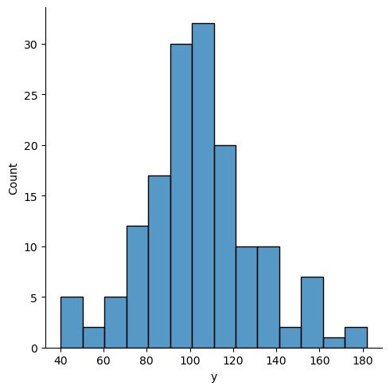

```python
sns.displot(data = df, x="y", kind="hist")

plt.show()
```

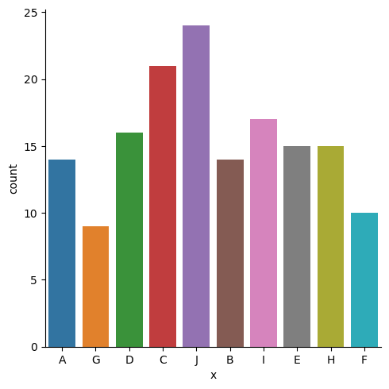

```python
sns.catplot(data=df, x="x", kind="count", hue="x")

plt.show()
```

Categorical to continous relationship. We want to know how the CONTINUPUS OUTPUT relates to the CATEGORICAL INPUT!

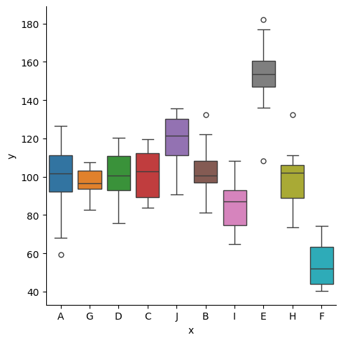

```python
sns.catplot(data=df, x="x", y="y", hue="x", kind="box")

plt.show()
```

Lets now examine if the AVERAGE OUTPUT is different across the categories of categorical input!!!

This is visualized with a POINT PLOT!!

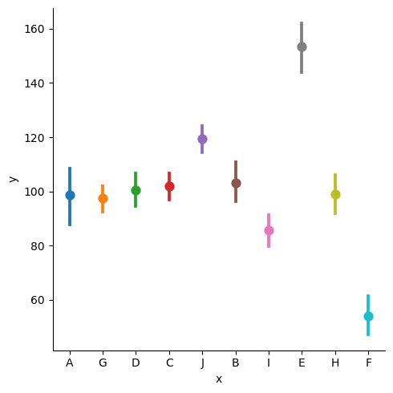

```python
sns.catplot(data=df, x="x", y="y", hue="x", kind="point", linestyle=None)

plt.show()
```

Why does this matter when we are talking about LINEAR MODELS???

We have learned that LINEAR MODLS are fundamentally MODELING the AVERAGE OUTPUT!!!

When you have CATEGORICAL INPUTS..the goal of the LINEAR MODEL is to PREDICT the AVERAGE OUTPUT PER CATEGORY!!!

But how can it PREDICT a continuous value when the INPUT is CATEGORICAL?????

```python
df
```

|  | x | y |
| --- | --- | --- |
| 0 | A | 103.324129 |
| 1 | G | 96.530846 |
| 2 | D | 95.772873 |
| 3 | C | 100.190541 |
| 4 | J | 129.608242 |
| ... | ... | ... |
| 150 | B | 92.286905 |
| 151 | I | 74.533121 |
| 152 | F | 46.537280 |
| 153 | C | 83.826336 |
| 154 | E | 176.863684 |

155 rows × 2 columns

## Fit a linear model to find out

Fit a linear model that has a LINEAR ADDITIVE relationship between the AVERAGE OUTPUT (trend) and the INPUT!!

```python
fit_a = smf.ols(formula="y ~ x", data=df).fit()
```

```python
fit_a.summary()
```

OLS Regression Results

| Dep. Variable: | y | R-squared: | 0.722 |
| --- | --- | --- | --- |
| Model: | OLS | Adj. R-squared: | 0.705 |
| Method: | Least Squares | F-statistic: | 41.84 |
| Date: | Sat, 16 Nov 2024 | Prob (F-statistic): | 4.99e-36 |
| Time: | 01:42:08 | Log-Likelihood: | -624.65 |
| No. Observations: | 155 | AIC: | 1269. |
| Df Residuals: | 145 | BIC: | 1300. |
| Df Model: | 9 |  |  |
| Covariance Type: | nonrobust |  |  |

|  | coef | std err | t | P>\|t\| | [0.025 | 0.975] |
| --- | --- | --- | --- | --- | --- | --- |
| Intercept | 98.7277 | 3.762 | 26.246 | 0.000 | 91.293 | 106.162 |
| x[T.B] | 4.4743 | 5.320 | 0.841 | 0.402 | -6.040 | 14.989 |
| x[T.C] | 3.1757 | 4.856 | 0.654 | 0.514 | -6.422 | 12.774 |
| x[T.D] | 1.7951 | 5.151 | 0.349 | 0.728 | -8.385 | 11.976 |
| x[T.E] | 54.6541 | 5.230 | 10.449 | 0.000 | 44.316 | 64.992 |
| x[T.F] | -44.8060 | 5.828 | -7.689 | 0.000 | -56.324 | -33.288 |
| x[T.G] | -1.2160 | 6.013 | -0.202 | 0.840 | -13.101 | 10.669 |
| x[T.H] | 0.3187 | 5.230 | 0.061 | 0.951 | -10.019 | 10.656 |
| x[T.I] | -13.0416 | 5.080 | -2.567 | 0.011 | -23.081 | -3.002 |
| x[T.J] | 20.8363 | 4.733 | 4.402 | 0.000 | 11.481 | 30.191 |

| Omnibus: | 3.100 | Durbin-Watson: | 1.815 |
| --- | --- | --- | --- |
| Prob(Omnibus): | 0.212 | Jarque-Bera (JB): | 2.609 |
| Skew: | -0.280 | Prob(JB): | 0.271 |
| Kurtosis: | 3.301 | Cond. No. | 11.5 |

Notes:  
[1] Standard Errors assume that the covariance matrix of the errors is correctly specified.

But when you have NON-NUMERIC inputs...FEATURES must be DERIVED from the INPUT to allow MULTIPLYING the FEATURE with a SLOPE!!

This FEATURE is know as a **DUMMY VARIABLE**

The DUMMY is a BINARY INDICTATOR... it is equal to 0 or 1.

IF the DUMMY is equal to 1, then the categorical variable EQUALS that category.

IF the DUMMY does NOT equal 1 or equals 0, then the categorical variable does NOT equal that category!!

How many DUMMY VARIABLES are created??

The number of categories MINUS 1!!!

```python
df.x.nunique()
```

```
10
```

```python
df.x.nunique() - 1
```

```
9
```

### DUMMY VARIABLE slopes

```python
fit_a.params
```

```
Intercept    98.727693
x[T.B]        4.474303
x[T.C]        3.175725
x[T.D]        1.795108
x[T.E]       54.654056
x[T.F]      -44.805967
x[T.G]       -1.216043
x[T.H]        0.318738
x[T.I]      -13.041580
x[T.J]       20.836328
dtype: float64
```

Look at the AVERAGE OUTPUT for each CATEGORY.

```python
df.groupby("x").aggregate(avg_y = ("y", "mean")).reset_index()
```

|  | x | avg_y |
| --- | --- | --- |
| 0 | A | 98.727693 |
| 1 | B | 103.201995 |
| 2 | C | 101.903418 |
| 3 | D | 100.522801 |
| 4 | E | 153.381749 |
| 5 | F | 53.921726 |
| 6 | G | 97.511650 |
| 7 | H | 99.046431 |
| 8 | I | 85.686113 |
| 9 | J | 119.564021 |

```python
avg_y_at_xA = df.loc[df.x=="A", "y"].mean()
```

```python
avg_y_at_xA
```

```
98.72769293463894
```

```python
df_summary = df.groupby("x").aggregate(avg_y = ("y", "mean")).reset_index()
```

```python
df_summary["avg_at_xA"] = avg_y_at_xA
```

```python
df_summary
```

|  | x | avg_y | avg_at_xA |
| --- | --- | --- | --- |
| 0 | A | 98.727693 | 98.727693 |
| 1 | B | 103.201995 | 98.727693 |
| 2 | C | 101.903418 | 98.727693 |
| 3 | D | 100.522801 | 98.727693 |
| 4 | E | 153.381749 | 98.727693 |
| 5 | F | 53.921726 | 98.727693 |
| 6 | G | 97.511650 | 98.727693 |
| 7 | H | 99.046431 | 98.727693 |
| 8 | I | 85.686113 | 98.727693 |
| 9 | J | 119.564021 | 98.727693 |

```python
df_summary["relative_difference_to_xA"] = df_summary.avg_y - df_summary.avg_at_xA
```

```python
df_summary.round(3)
```

|  | x | avg_y | avg_at_xA | relative_difference_to_xA |
| --- | --- | --- | --- | --- |
| 0 | A | 98.728 | 98.728 | -0.000 |
| 1 | B | 103.202 | 98.728 | 4.474 |
| 2 | C | 101.903 | 98.728 | 3.176 |
| 3 | D | 100.523 | 98.728 | 1.795 |
| 4 | E | 153.382 | 98.728 | 54.654 |
| 5 | F | 53.922 | 98.728 | -44.806 |
| 6 | G | 97.512 | 98.728 | -1.216 |
| 7 | H | 99.046 | 98.728 | 0.319 |
| 8 | I | 85.686 | 98.728 | -13.042 |
| 9 | J | 119.564 | 98.728 | 20.836 |

```python
fit_a.params
```

```
Intercept    98.727693
x[T.B]        4.474303
x[T.C]        3.175725
x[T.D]        1.795108
x[T.E]       54.654056
x[T.F]      -44.805967
x[T.G]       -1.216043
x[T.H]        0.318738
x[T.I]      -13.041580
x[T.J]       20.836328
dtype: float64
```

When DUMMY VARIABLES are DEFINED a **REFERENCE category** MUST be DEFINED!!!

ALL DUMMY SLOPES are calculated RELATIVE to this REFERENCE POINT!!! By default, the REFERENCE CATEGORY is the FIRST alphabetical category!!!

The INTERCEPT is the AVERAGE at the REFERENCE!!

When we examine statistical significance, we are asking is there a STATISTICALLY SIGNIFICANT difference in the AVERAGE OUTPUT from the REFERENCE category!!!

```python
fit_a.summary()
```

OLS Regression Results

| Dep. Variable: | y | R-squared: | 0.722 |
| --- | --- | --- | --- |
| Model: | OLS | Adj. R-squared: | 0.705 |
| Method: | Least Squares | F-statistic: | 41.84 |
| Date: | Sat, 16 Nov 2024 | Prob (F-statistic): | 4.99e-36 |
| Time: | 01:57:52 | Log-Likelihood: | -624.65 |
| No. Observations: | 155 | AIC: | 1269. |
| Df Residuals: | 145 | BIC: | 1300. |
| Df Model: | 9 |  |  |
| Covariance Type: | nonrobust |  |  |

|  | coef | std err | t | P>\|t\| | [0.025 | 0.975] |
| --- | --- | --- | --- | --- | --- | --- |
| Intercept | 98.7277 | 3.762 | 26.246 | 0.000 | 91.293 | 106.162 |
| x[T.B] | 4.4743 | 5.320 | 0.841 | 0.402 | -6.040 | 14.989 |
| x[T.C] | 3.1757 | 4.856 | 0.654 | 0.514 | -6.422 | 12.774 |
| x[T.D] | 1.7951 | 5.151 | 0.349 | 0.728 | -8.385 | 11.976 |
| x[T.E] | 54.6541 | 5.230 | 10.449 | 0.000 | 44.316 | 64.992 |
| x[T.F] | -44.8060 | 5.828 | -7.689 | 0.000 | -56.324 | -33.288 |
| x[T.G] | -1.2160 | 6.013 | -0.202 | 0.840 | -13.101 | 10.669 |
| x[T.H] | 0.3187 | 5.230 | 0.061 | 0.951 | -10.019 | 10.656 |
| x[T.I] | -13.0416 | 5.080 | -2.567 | 0.011 | -23.081 | -3.002 |
| x[T.J] | 20.8363 | 4.733 | 4.402 | 0.000 | 11.481 | 30.191 |

| Omnibus: | 3.100 | Durbin-Watson: | 1.815 |
| --- | --- | --- | --- |
| Prob(Omnibus): | 0.212 | Jarque-Bera (JB): | 2.609 |
| Skew: | -0.280 | Prob(JB): | 0.271 |
| Kurtosis: | 3.301 | Cond. No. | 11.5 |

Notes:  
[1] Standard Errors assume that the covariance matrix of the errors is correctly specified.

```python
def my_coefplot(mod, figsize_use=(10,4)):
    fig, ax = plt.subplots(figsize=figsize_use)

    ax.errorbar(y=mod.params.index,
               x=mod.params,
               xerr=2*mod.bse, fmt="o", color="k", ecolor="k", elinewidth=2, ms=10)

    ax.axvline(x=0, linestyle="--", linewidth=3.5, color="grey")

    ax.set_xlabel("coefficient value")

    plt.show()
```

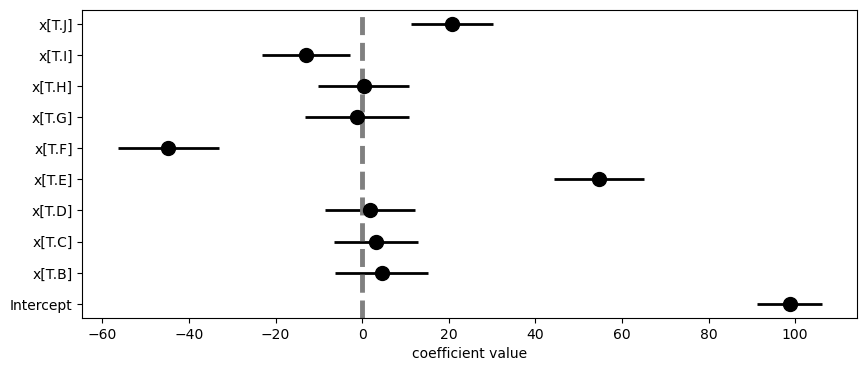

```python
my_coefplot(fit_a)
```

If we predict with our MODEL it will only predict at the observed CATEGORIES!!!

```python
input_grid = pd.DataFrame({"x": df.x.unique()}).sort_values("x", ignore_index=True)
```

```python
input_grid
```

|  | x |
| --- | --- |
| 0 | A |
| 1 | B |
| 2 | C |
| 3 | D |
| 4 | E |
| 5 | F |
| 6 | G |
| 7 | H |
| 8 | I |
| 9 | J |

```python
fit_a.predict(input_grid)
```

```
0     98.727693
1    103.201995
2    101.903418
3    100.522801
4    153.381749
5     53.921726
6     97.511650
7     99.046431
8     85.686113
9    119.564021
dtype: float64
```

```python
df_summary["pred_from_summaries"] = fit_a.predict(input_grid)
```

```python
df_summary
```

|  | x | avg_y | avg_at_xA | relative_difference_to_xA | pred_from_summaries |
| --- | --- | --- | --- | --- | --- |
| 0 | A | 98.727693 | 98.727693 | -2.842171e-14 | 98.727693 |
| 1 | B | 103.201995 | 98.727693 | 4.474303e+00 | 103.201995 |
| 2 | C | 101.903418 | 98.727693 | 3.175725e+00 | 101.903418 |
| 3 | D | 100.522801 | 98.727693 | 1.795108e+00 | 100.522801 |
| 4 | E | 153.381749 | 98.727693 | 5.465406e+01 | 153.381749 |
| 5 | F | 53.921726 | 98.727693 | -4.480597e+01 | 53.921726 |
| 6 | G | 97.511650 | 98.727693 | -1.216043e+00 | 97.511650 |
| 7 | H | 99.046431 | 98.727693 | 3.187382e-01 | 99.046431 |
| 8 | I | 85.686113 | 98.727693 | -1.304158e+01 | 85.686113 |
| 9 | J | 119.564021 | 98.727693 | 2.083633e+01 | 119.564021 |

## An alternative

An alternative approach is to REMOVE the intercept. This is known as the ONE-HOT encoding!!!

REMOVE the INTERCEPT using the `- 1` operator in the FORMULA interface!!!

```python
fit_b = smf.ols(formula="y ~ x - 1", data=df).fit()
```

```python
fit_b.params
```

```
x[A]     98.727693
x[B]    103.201995
x[C]    101.903418
x[D]    100.522801
x[E]    153.381749
x[F]     53.921726
x[G]     97.511650
x[H]     99.046431
x[I]     85.686113
x[J]    119.564021
dtype: float64
```

The estimate coefficients whe ONE HOT encoding is used...corresponds DIRECTLY to the AVERAGE OUTPUT per category!!!

```python
fit_b.params.reset_index(drop=True)
```

```
0     98.727693
1    103.201995
2    101.903418
3    100.522801
4    153.381749
5     53.921726
6     97.511650
7     99.046431
8     85.686113
9    119.564021
dtype: float64
```

```python
df_summary["onehot_coefs"] = pd.Series(fit_b.params.reset_index(drop=True), index=df_summary.index)
```

```python
df_summary
```

|  | x | avg_y | avg_at_xA | relative_difference_to_xA | pred_from_summaries | onehot_coefs |
| --- | --- | --- | --- | --- | --- | --- |
| 0 | A | 98.727693 | 98.727693 | -2.842171e-14 | 98.727693 | 98.727693 |
| 1 | B | 103.201995 | 98.727693 | 4.474303e+00 | 103.201995 | 103.201995 |
| 2 | C | 101.903418 | 98.727693 | 3.175725e+00 | 101.903418 | 101.903418 |
| 3 | D | 100.522801 | 98.727693 | 1.795108e+00 | 100.522801 | 100.522801 |
| 4 | E | 153.381749 | 98.727693 | 5.465406e+01 | 153.381749 | 153.381749 |
| 5 | F | 53.921726 | 98.727693 | -4.480597e+01 | 53.921726 | 53.921726 |
| 6 | G | 97.511650 | 98.727693 | -1.216043e+00 | 97.511650 | 97.511650 |
| 7 | H | 99.046431 | 98.727693 | 3.187382e-01 | 99.046431 | 99.046431 |
| 8 | I | 85.686113 | 98.727693 | -1.304158e+01 | 85.686113 | 85.686113 |
| 9 | J | 119.564021 | 98.727693 | 2.083633e+01 | 119.564021 | 119.564021 |

```python
df_summary["pred_from_onehot"] = fit_b.predict(input_grid)
```

```python
df_summary
```

|  | x | avg_y | avg_at_xA | relative_difference_to_xA | pred_from_summaries | onehot_coefs | pred_from_onehot |
| --- | --- | --- | --- | --- | --- | --- | --- |
| 0 | A | 98.727693 | 98.727693 | -2.842171e-14 | 98.727693 | 98.727693 | 98.727693 |
| 1 | B | 103.201995 | 98.727693 | 4.474303e+00 | 103.201995 | 103.201995 | 103.201995 |
| 2 | C | 101.903418 | 98.727693 | 3.175725e+00 | 101.903418 | 101.903418 | 101.903418 |
| 3 | D | 100.522801 | 98.727693 | 1.795108e+00 | 100.522801 | 100.522801 | 100.522801 |
| 4 | E | 153.381749 | 98.727693 | 5.465406e+01 | 153.381749 | 153.381749 | 153.381749 |
| 5 | F | 53.921726 | 98.727693 | -4.480597e+01 | 53.921726 | 53.921726 | 53.921726 |
| 6 | G | 97.511650 | 98.727693 | -1.216043e+00 | 97.511650 | 97.511650 | 97.511650 |
| 7 | H | 99.046431 | 98.727693 | 3.187382e-01 | 99.046431 | 99.046431 | 99.046431 |
| 8 | I | 85.686113 | 98.727693 | -1.304158e+01 | 85.686113 | 85.686113 | 85.686113 |
| 9 | J | 119.564021 | 98.727693 | 2.083633e+01 | 119.564021 | 119.564021 | 119.564021 |

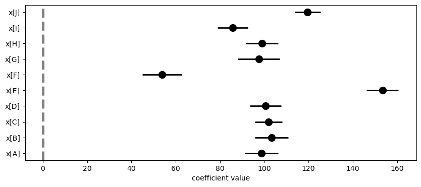

```python
my_coefplot(fit_b)
```

```python
fit_b.pvalues
```

```
x[A]    6.050418e-57
x[B]    2.853747e-59
x[C]    1.336084e-69
x[D]    2.007076e-61
x[E]    2.470158e-83
x[F]    8.918906e-24
x[G]    2.494152e-45
x[H]    6.370110e-59
x[I]    1.221516e-54
x[J]    1.629293e-82
dtype: float64
```

```python
fit_b.pvalues < 0.05
```

```
x[A]    True
x[B]    True
x[C]    True
x[D]    True
x[E]    True
x[F]    True
x[G]    True
x[H]    True
x[I]    True
x[J]    True
dtype: bool
```

ONE HOT ENCODING causes you to NO LONGER be able to use the p-values to identify statistical significance!!!!